# Report of exercise 2

In the beginning of this week, I tried to recall what is regression analysis and read about it in Kimmo’s textbook. Doing exercises I found it very helpful that I had used regression analysis before, even though not in R. The data camp exercises were very useful. This week I found most difficult the “project managing” parts of the exercises: saving the data, knitting, and understanding, which file to use etc. Anyway, I am confident that I succeeded for the most part :)

## Part 1.

I read the data to RMarkdown-file. It was hard for me to realize the details of the data saving and reading process, mut eventually I got it done, **yippii!** Then I explored the structure of the dataset. I noticed that the variable “gender” was type “character”, which was a problem later, so I changed it to be type “factor”.

```r
sub_learning2014 <- read.csv("data/Learning2014_SUBSET.csv", sep = ",", header = TRUE)
sub_learning2014$gender <- as.factor(sub_learning2014$gender)
str(sub_learning2014)
```

```
## 'data.frame':    166 obs. of  7 variables:
##  $ gender  : Factor w/ 2 levels "F","M": 1 2 1 2 2 1 2 1 2 1 ...
##  $ Age     : int  53 55 49 53 49 38 50 37 37 42 ...
##  $ attitude: num  3.7 3.1 2.5 3.5 3.7 3.8 3.5 2.9 3.8 2.1 ...
##  $ deep    : num  3.58 2.92 3.5 3.5 3.67 ...
##  $ stra    : num  3.38 2.75 3.62 3.12 3.62 ...
##  $ surf    : num  2.58 3.17 2.25 2.25 2.83 ...
##  $ Points  : int  25 12 24 10 22 21 21 31 24 26 ...
```

```r
dim(sub_learning2014)
```

```
## [1] 166   7
```

**My description of the dataset**: The data is based on the survey of approaches to learning, which was implemented on a statistics course in fall 2014. The data includes 166 subjects and 7 variables: gender, age, attitude towards statistics (on a scale of 1-5), learning strategies (variables *deep*, *stra* and *surf*, on scales of 1-5), and exam points.

## Part 2.

Next, I will explore the distributions and correlations of the variables. Don’t get confused with the order of the boxplots - I will draw first the boxplots of *Age* and *Points* and then the boxplots of the rest of the variables since *attitude*, *deep*, *stra* and *surf* all have the same scales. Below, I comment on the distributions and the correlations of the variables.

```r
summary (sub_learning2014)
```

```
##  gender       Age           attitude          deep            stra
##  F:110   Min.   :17.00   Min.   :1.400   Min.   :1.583   Min.   :1.250
##  M: 56   1st Qu.:21.00   1st Qu.:2.600   1st Qu.:3.333   1st Qu.:2.625
##          Median :22.00   Median :3.200   Median :3.667   Median :3.188
##          Mean   :25.51   Mean   :3.143   Mean   :3.680   Mean   :3.121
##          3rd Qu.:27.00   3rd Qu.:3.700   3rd Qu.:4.083   3rd Qu.:3.625
##          Max.   :55.00   Max.   :5.000   Max.   :4.917   Max.   :5.000
##       surf           Points
##  Min.   :1.583   Min.   : 7.00
##  1st Qu.:2.417   1st Qu.:19.00
##  Median :2.833   Median :23.00
##  Mean   :2.787   Mean   :22.72
##  3rd Qu.:3.167   3rd Qu.:27.75
##  Max.   :4.333   Max.   :33.00
```

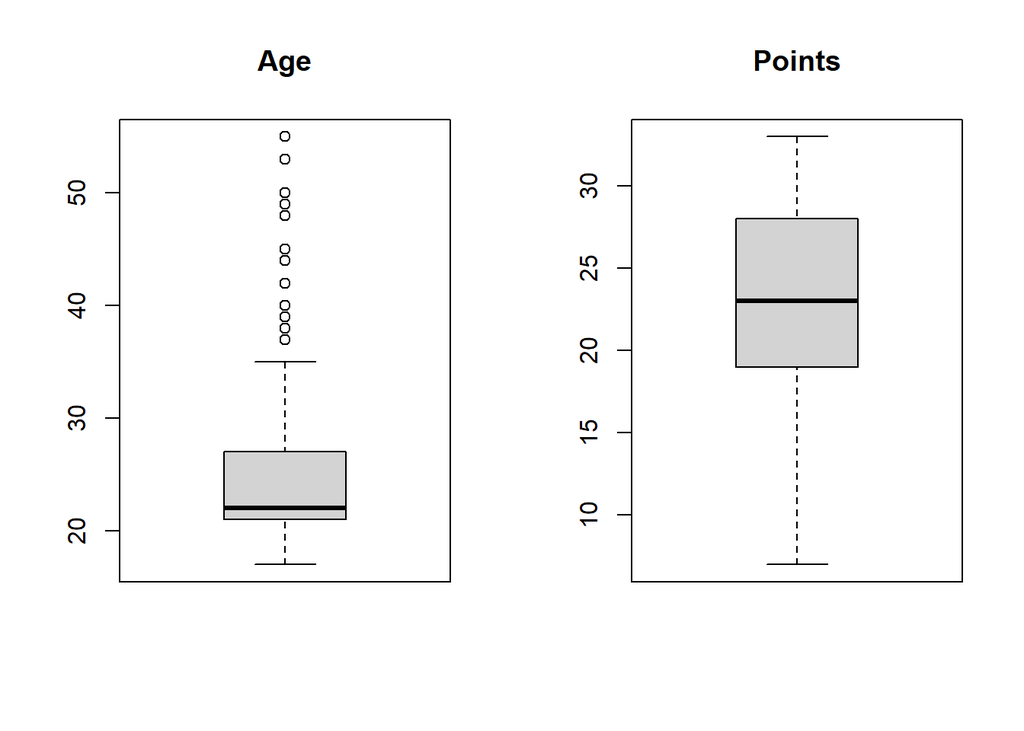

```r
par(mfrow=c(1,2))
boxplot(sub_learning2014$Age, main = "Age")
boxplot (sub_learning2014$Points, main = "Points")
```

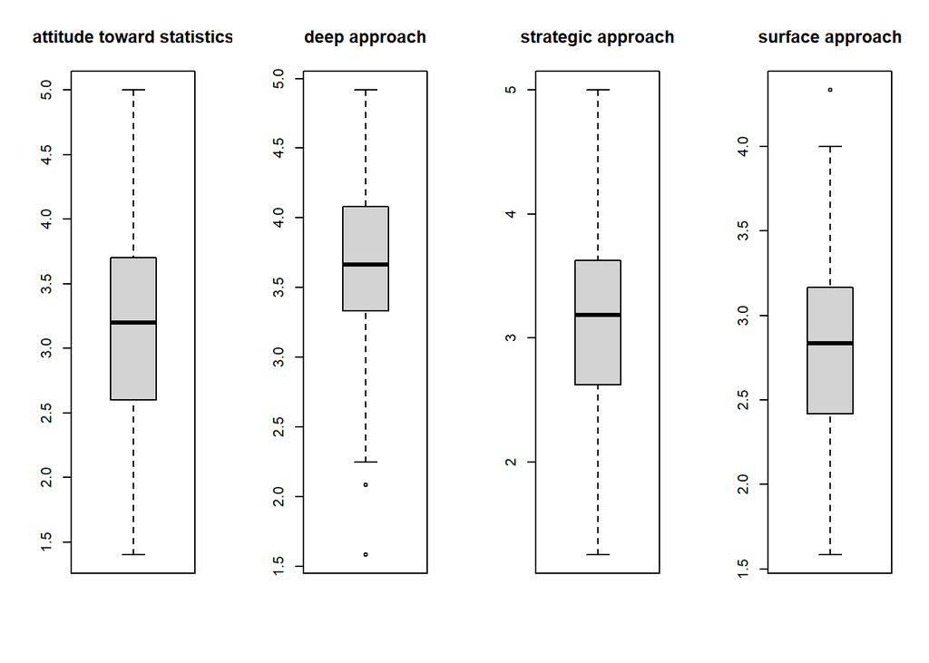

```r
par(mfrow=c(1,4))
boxplot (sub_learning2014$attitude, main = "attitude toward statistics")
boxplot (sub_learning2014$deep, main = "deep approach")
boxplot (sub_learning2014$stra, main = "strategic approach")
boxplot (sub_learning2014$surf, main = "surface approach")
```

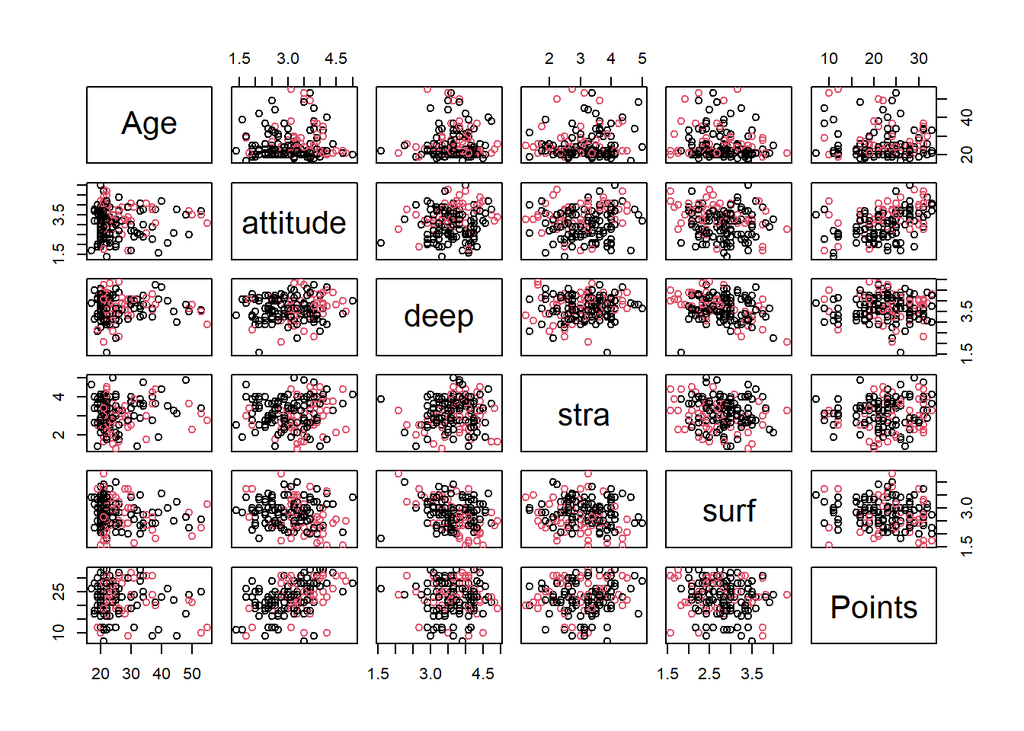

```r
pairs(sub_learning2014[-1], col = sub_learning2014$gender)
library(GGally)
```

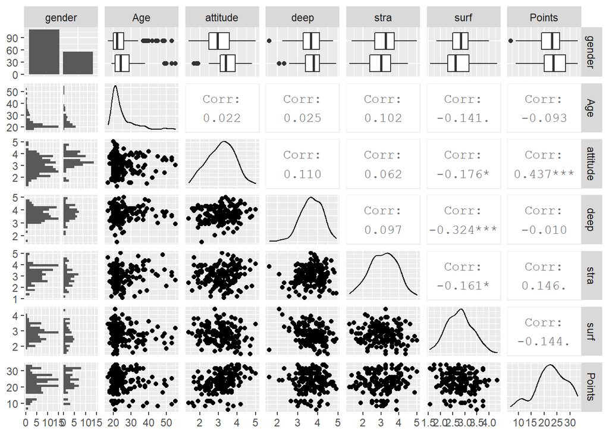

```r
library(ggplot2)

ggpairs(sub_learning2014, lower = list(combo = wrap("facethist", bins = 20)))
```

- The distribution of gender: about 2/3 of the subjects are women
- The distribution of *Age* is skewed towards the lower end of the scale with 75 % of the observations falling between (17,27).
- The distribution of *Points* is pretty normal too. The observations seem to focus a little more on the upper side of the distribution.
- The distribution of *attitude* is normal, not skewed, and seemes to have no outliers.
- The distribution of *deep* is quite normal, and has two potential outliers in the lower end of the distribution.
- The distribution of *stra* looks normal and seems to have no outliers.
- The distribution of *surf* also looks normal and has one potential outlier in the upper end of the distribution.

The strongest correlations are

- *attitude* vs *Points* (positive***)
- *deep* vs *surf* (negative***)
- *surf* vs *attitude* (negative*)
- *surf* vs *stra* (negative*)
- *stra* vs *Points* (positive)
- *surf* vs *Points* (negative)
- *surf* vs *Age* (negative)
- *stra* vs *Age* (positive)

I find these correlations quite logical, e.g. good attitude is related with better points in the exam; if a student has good attitude, then they probably use less surface learning strategies; if a student uses more surface learning strategies, then the points of the exam are probably lower etc. Overall, these correlations are not very strong and only the first four correlations in the list are statistically significant.

## Part3.

Next, I will fit a regression model in which exam points is the target variable. I choose the explanatory variables (3) by the correlations shown above. The strongest correlations with *Points* are found with *attitude*, *stra* and *surf*.

```r
reg_model_3 <- lm(Points ~ attitude + stra + surf, data = sub_learning2014)
summary(reg_model_3)
```

```
##
## Call:
## lm(formula = Points ~ attitude + stra + surf, data = sub_learning2014)
##
## Residuals:
##      Min       1Q   Median       3Q      Max
## -17.1550  -3.4346   0.5156   3.6401  10.8952
##
## Coefficients:
##             Estimate Std. Error t value Pr(>|t|)
## (Intercept)  11.0171     3.6837   2.991  0.00322 **
## attitude      3.3952     0.5741   5.913 1.93e-08 ***
## stra          0.8531     0.5416   1.575  0.11716
## surf         -0.5861     0.8014  -0.731  0.46563
## ---
## Signif. codes:  0 '***' 0.001 '**' 0.01 '*' 0.05 '.' 0.1 ' ' 1
##
## Residual standard error: 5.296 on 162 degrees of freedom
## Multiple R-squared:  0.2074, Adjusted R-squared:  0.1927
## F-statistic: 14.13 on 3 and 162 DF,  p-value: 3.156e-08
```

I notice that the only explanatory variable that is significant is attitude. These is not surprising since the variables *stra* or *surf* didn’t have a strong correlation with *Points* to begin with. Still, I don’t know whether multicollinearity has something to do with this non-significance, since I noticed that the variables *stra* and *surf* correlate. I decide to fit the model with both of these variables separately:

```r
reg_model_2a <- lm(Points ~ attitude + stra, data = sub_learning2014)
summary(reg_model_2a)
```

```
##
## Call:
## lm(formula = Points ~ attitude + stra, data = sub_learning2014)
##
## Residuals:
##      Min       1Q   Median       3Q      Max
## -17.6436  -3.3113   0.5575   3.7928  10.9295
##
## Coefficients:
##             Estimate Std. Error t value Pr(>|t|)
## (Intercept)   8.9729     2.3959   3.745  0.00025 ***
## attitude      3.4658     0.5652   6.132 6.31e-09 ***
## stra          0.9137     0.5345   1.709  0.08927 .
## ---
## Signif. codes:  0 '***' 0.001 '**' 0.01 '*' 0.05 '.' 0.1 ' ' 1
##
## Residual standard error: 5.289 on 163 degrees of freedom
## Multiple R-squared:  0.2048, Adjusted R-squared:  0.1951
## F-statistic: 20.99 on 2 and 163 DF,  p-value: 7.734e-09
```

```r
reg_model_2b <- lm(Points ~ attitude + surf, data = sub_learning2014)
summary(reg_model_2b)
```

```
##
## Call:
## lm(formula = Points ~ attitude + surf, data = sub_learning2014)
##
## Residuals:
##     Min      1Q  Median      3Q     Max
## -17.277  -3.236   0.386   3.977  10.642
##
## Coefficients:
##             Estimate Std. Error t value Pr(>|t|)
## (Intercept)  14.1196     3.1271   4.515 1.21e-05 ***
## attitude      3.4264     0.5764   5.944 1.63e-08 ***
## surf         -0.7790     0.7956  -0.979    0.329
## ---
## Signif. codes:  0 '***' 0.001 '**' 0.01 '*' 0.05 '.' 0.1 ' ' 1
##
## Residual standard error: 5.32 on 163 degrees of freedom
## Multiple R-squared:  0.1953, Adjusted R-squared:  0.1854
## F-statistic: 19.78 on 2 and 163 DF,  p-value: 2.041e-08
```

After deleting *surf* from the model, the explanatory variable *stra* came closer to the limit of significance. However, it didn’t still reach the significance.

After deleting *stra* from the model, the explanatory variable *surf* still wasn’t significant.

So, it seems that the best model would include only the intercept and the explanatory variable *attitude*. Next, I’ll fit this model:

```r
reg_model_1 <- lm(Points ~ attitude , data = sub_learning2014)
summary(reg_model_1)
```

```
##
## Call:
## lm(formula = Points ~ attitude, data = sub_learning2014)
##
## Residuals:
##      Min       1Q   Median       3Q      Max
## -16.9763  -3.2119   0.4339   4.1534  10.6645
##
## Coefficients:
##             Estimate Std. Error t value Pr(>|t|)
## (Intercept)  11.6372     1.8303   6.358 1.95e-09 ***
## attitude      3.5255     0.5674   6.214 4.12e-09 ***
## ---
## Signif. codes:  0 '***' 0.001 '**' 0.01 '*' 0.05 '.' 0.1 ' ' 1
##
## Residual standard error: 5.32 on 164 degrees of freedom
## Multiple R-squared:  0.1906, Adjusted R-squared:  0.1856
## F-statistic: 38.61 on 1 and 164 DF,  p-value: 4.119e-09
```